# Assignment1

### *Wei Chen 5207679*

### *Jan/29/2016*

## Exercise 1.4:

1. plot the scatter diagram with marginal boxplots for sales and profits variables
2. compute $\bar{\mathbb{x}}$<sub>1</sub> ,$\bar{\mathbb{x}}$<sub>2</sub>, s<sub>11</sub>, s<sub>22</sub>, s<sub>12</sub> and r<sub>12</sub>

## Solution:

(a)First, I need to install packages “alr4” and then library it.

```r
install.packages("alr4",repos = 'http://cran.us.r-project.org')
library(alr4)
```

Now I import data:

```r
p1_4 <-read.table("http://users.stat.umn.edu/~guxxx192/courses/wichern_data/p1-4.dat")
```

I add the column and plot the scatter diagram with marginal boxplots

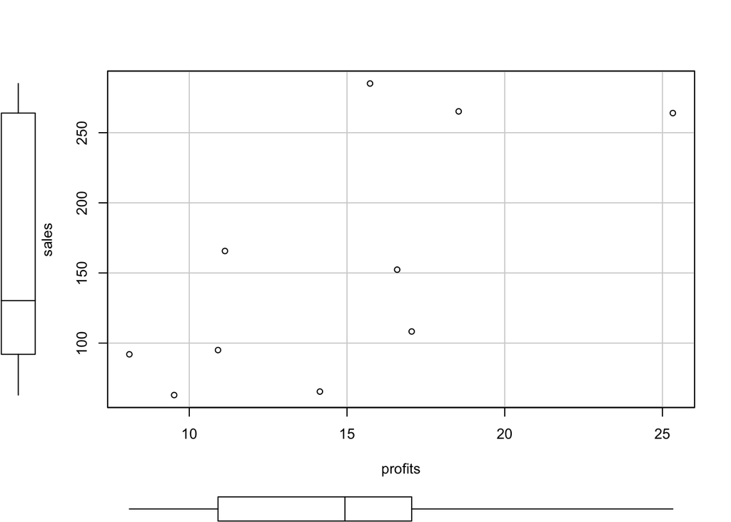

```r
colnames(p1_4) <- c("sales","profits","assets")
scatterplot(sales ~ profits, data= p1_4, smoother= F, reg.line= F)
```

（b）In order to calculate sales and profits variablrs, I first remove other variables and create a new data set p1_4_new

```r
p1_4_new <-p1_4[,c("sales","profits")]
```

And then print the mean of sales and profits

```r
print(colMeans(p1_4_new))
```

```
##   sales profits
## 155.603  14.704
```

Now I calculate the variance matrix and print S_1_1, S_2_2, S_1_2

```r
S=var(p1_4_new)
c(S[1,1] ,S[2,2],S[1,2])
```

```
## [1] 7476.45325   26.19032  303.61862
```

Calculate the correlation and print the r_1_2

```r
C<- cor(p1_4_new)
C[1,2]
```

```
## [1] 0.686136
```

It shows that correlation 0.68 between sales and profits is positive which proximately means positive linear association. They change almost in same direction that the more sales is, the more the profits is.

## Exercise 1.5

Use the data in Exercise 1.4 (a) plot the scatter diagrams and boxplots for (x<sub>2</sub>, x<sub>3</sub>), (x<sub>1</sub>, x<sub>3</sub>). Comment on the patterns (b) Compute the $\bar{\mathbb{x}}$, S<sub>n</sub>, and R arrays for (x<sub>1</sub>, x<sub>2</sub>, x<sub>3</sub>)

## Solution:

1. Plot (x<sub>2</sub>, x<sub>3</sub>) and find no explicit pattern. The same amount of assets corresponds to different profits.

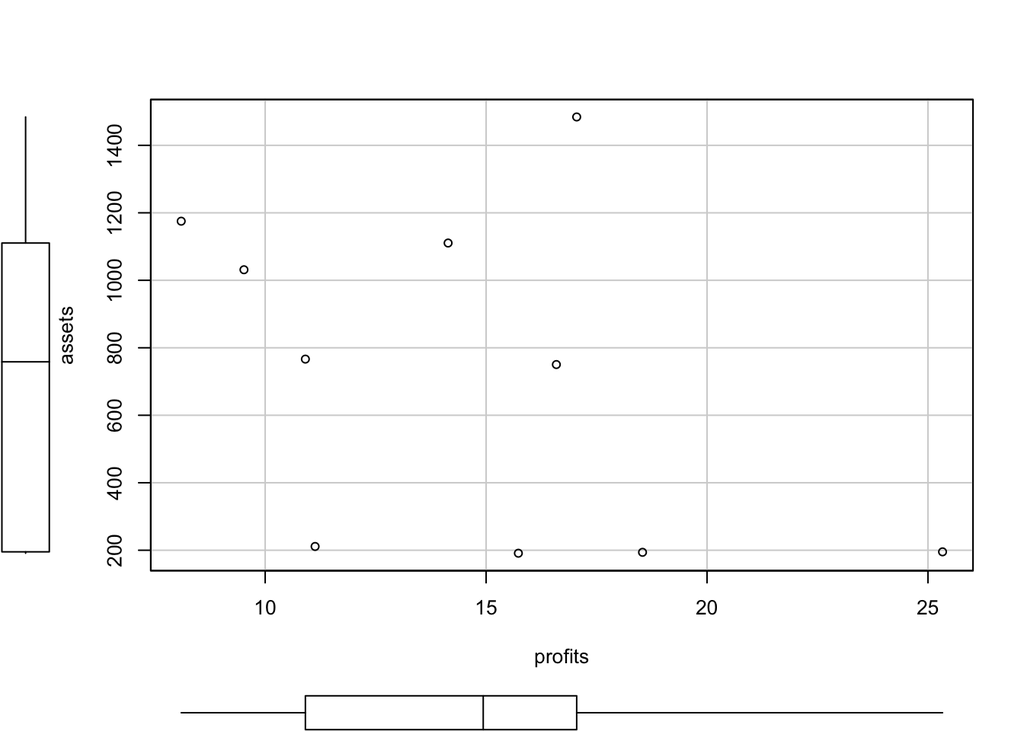

```r
scatterplot(assets~profits, data= p1_4, smoother=F, reg.line= F)
```

plot (x<sub>1</sub>, x<sub>3</sub>) and find that assets go down as the sales become larger

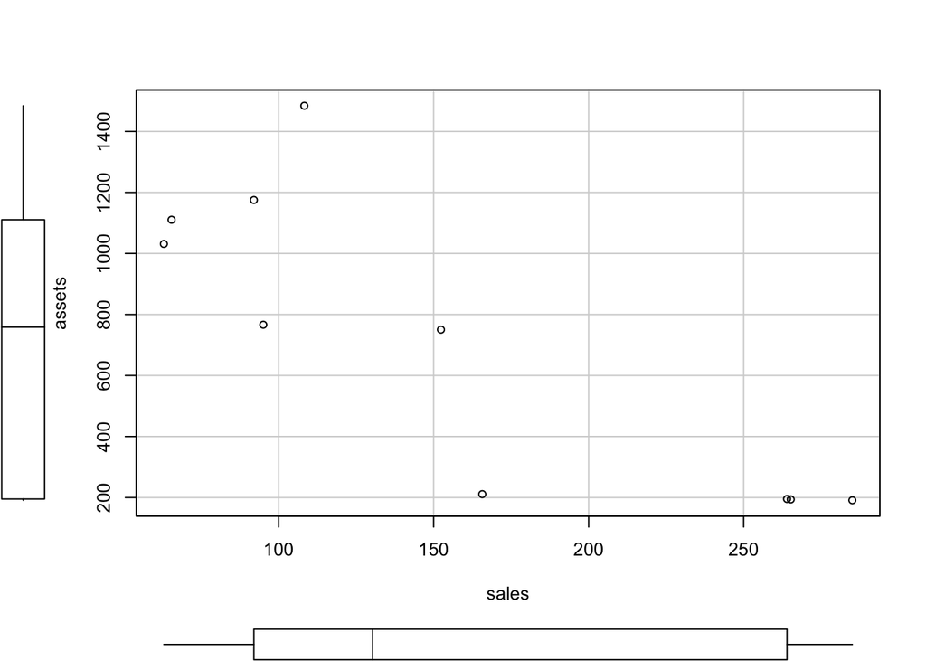

```r
scatterplot(assets~sales, data =p1_4, smoother= F, reg.line= F)
```

2. array X_mean=

```r
colMeans(p1_4)
```

```
##   sales profits  assets
## 155.603  14.704 710.911
```

variance matrix S_n =

```r
var(p1_4)
```

```
##               sales     profits     assets
## sales     7476.4532   303.61862 -35575.960
## profits    303.6186    26.19032  -1053.827
## assets  -35575.9596 -1053.82739 237054.270
```

correlation matrix R_n =

```r
cor(p1_4)
```

```
##              sales    profits     assets
## sales    1.0000000  0.6861360 -0.8450549
## profits  0.6861360  1.0000000 -0.4229366
## assets  -0.8450549 -0.4229366  1.0000000
```

## Exercise 1.15

Some of the 98 measurements described in Section 1.2 are listed in Table 1.7. The data consists of average ratings over the course of treatment for patients undergoing reditherapy. Variables measured include x<sub>1</sub>(number of symptoms); x<sub>2</sub>(amount of activity); x<sub>3</sub>(amount of sleep,on a 1-5 scale); x<sub>4</sub>(amount of food consumed, on a 1-3 scale); x<sub>5</sub>(appetite, on a 1-5 scale); x<sub>6</sub>(skin reaction, on a 0-3 scale). (a) Construct the two-dimensional scatterplot for variables x<sub>2</sub> and x~3 and the margnal boxplots. Do there appear to be any errors in the x<sub>3</sub> data? (b)Compute the $\bar{\mathbb{x}}$, S<sub>n</sub>, and R arrays. Interpret the pairwise correlations.

## Solution:

(a)First I import data from http://users.stat.umn.edu/~guxxx192/courses/wichern_data/t1-7.dat

```r
t1_7<- read.table("http://users.stat.umn.edu/~guxxx192/courses/wichern_data/t1-7.dat")
```

I add column names and then conduct scatter plot with boxplots.x<sub>3</sub> should be included in 1-5 scale, but there is a few points lower than 1 and no points higher than 4. So there may be some mistake.

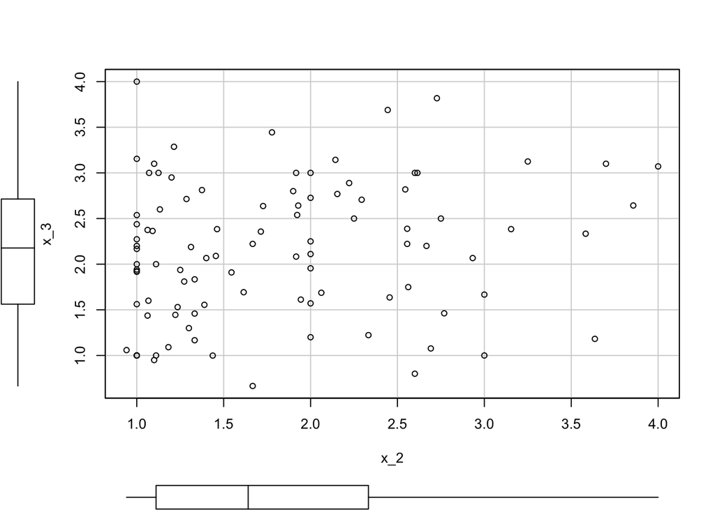

```r
colnames(t1_7)<-c("x_1","x_2","x_3","x_4","x_5","x_6")
scatterplot(x_3~x_2, data= t1_7, smoother=F, reg.line=F)
```

(b)Calculate the $\bar{\mathbb{x}}$ :

```r
colMeans(t1_7)
```

```
##      x_1      x_2      x_3      x_4      x_5      x_6
## 3.542347 1.809357 2.137602 2.209000 2.574827 1.275510
```

Calculate the S<sub>n</sub>:

```r
var(t1_7)
```

```
##           x_1         x_2        x_3        x_4          x_5          x_6
## x_1 4.6547509  0.93134537 0.58969909 0.27691531  1.074885659  0.158150852
## x_2 0.9313454  0.61282116 0.11093341 0.11846905  0.388886434 -0.024851988
## x_3 0.5896991  0.11093341 0.57142886 0.08700496  0.347989910  0.110131391
## x_4 0.2769153  0.11846905 0.08700496 0.11040907  0.217405649  0.021814433
## x_5 1.0748857  0.38888643 0.34798991 0.21740565  0.862172372 -0.008817694
## x_6 0.1581509 -0.02485199 0.11013139 0.02181443 -0.008817694  0.861455923
```

Calculate the R:

```r
cor(t1_7)
```

```
##            x_1         x_2       x_3        x_4         x_5         x_6
## x_1 1.00000000  0.55143669 0.3615773 0.38627479  0.53655840  0.07897812
## x_2 0.55143669  1.00000000 0.1874625 0.45544470  0.53500626 -0.03420407
## x_3 0.36157729  0.18746250 1.0000000 0.34638617  0.49577944  0.15696886
## x_4 0.38627479  0.45544470 0.3463862 1.00000000  0.70464665  0.07073348
## x_5 0.53655840  0.53500626 0.4957794 0.70464665  1.00000000 -0.01023155
## x_6 0.07897812 -0.03420407 0.1569689 0.07073348 -0.01023155  1.00000000
```

```r
t1_8<- read.table("http://users.stat.umn.edu/~guxxx192/courses/wichern_data/t1-8.dat")
```

Add the column names and calculate the mean $\bar{\mathbb{x}}$=

```r
colnames(t1_8)<- c( "Dominant radius","Radius", "Dominant humerus", "Humerus","Dominant ulna","Ulna")
colMeans(t1_8)
```

```
##  Dominant radius           Radius Dominant humerus          Humerus
##          0.84380          0.81832          1.79268          1.73484
##    Dominant ulna             Ulna
##          0.70440          0.69384
```

Calculate the variance S<sub>n</sub> =

```r
var(t1_8)
```

```
##                  Dominant radius      Radius Dominant humerus    Humerus
## Dominant radius      0.013001583 0.010378442       0.02234997 0.02008568
## Radius               0.010378442 0.011417893       0.01853519 0.02109951
## Dominant humerus     0.022349975 0.018535190       0.08035723 0.06677620
## Humerus              0.020085675 0.021099512       0.06677620 0.06948447
## Dominant ulna        0.009120708 0.008529783       0.01683692 0.01773548
## Ulna                 0.007957842 0.008908512       0.01284703 0.01679360
##                  Dominant ulna        Ulna
## Dominant radius    0.009120708 0.007957842
## Radius             0.008529783 0.008908512
## Dominant humerus   0.016836925 0.012847030
## Humerus            0.017735483 0.016793598
## Dominant ulna      0.011568417 0.008071150
## Ulna               0.008071150 0.010599140
```

Calculate the correlation R=

```r
cor(t1_8)
```

```
##                  Dominant radius    Radius Dominant humerus   Humerus
## Dominant radius        1.0000000 0.8518067        0.6914590 0.6682584
## Radius                 0.8518067 1.0000000        0.6119157 0.7490926
## Dominant humerus       0.6914590 0.6119157        1.0000000 0.8936456
## Humerus                0.6682584 0.7490926        0.8936456 1.0000000
## Dominant ulna          0.7436926 0.7421780        0.5522215 0.6255502
## Ulna                   0.6778941 0.8097983        0.4402050 0.6188203
##                  Dominant ulna      Ulna
## Dominant radius      0.7436926 0.6778941
## Radius               0.7421780 0.8097983
## Dominant humerus     0.5522215 0.4402050
## Humerus              0.6255502 0.6188203
## Dominant ulna        1.0000000 0.7288919
## Ulna                 0.7288919 1.0000000
```

```r
t1_9<- read.table("http://users.stat.umn.edu/~guxxx192/courses/wichern_data/t1-9.dat", sep="\t")
```

Add the column names and after reomve the “country column”, calculate the number of rows in table 1.9 in order to create the convert matrix to change the measurement to speed.

```r
colnames(t1_9)<-c("Country","100m","200m","400m","800m","1500m","3000m","Marathon")
t1_9_time<- t1_9[,-c(1)]
nrow(t1_9)
```

```
## [1] 54
```

Then create the convert matrix to change the measurement to speed as matirx, t1_9_speed.

```r
convert <-c(rep(100,54),rep(200,54),rep(400,54),rep(800/60,54),rep(1500/60,54),rep(3000/60,54),rep(42195/60,54))
t1_9_speed<- convert/t1_9_time
t1_9_speed
```

```
##        100m     200m     400m     800m    1500m    3000m Marathon
## 1  8.643042 8.718396 7.619048 6.504065 5.882353 5.440696 4.678353
## 2  8.992806 8.996851 8.225375 6.734007 6.218905 5.793743 4.900355
## 3  8.968610 8.810573 7.902015 6.872852 6.172840 5.694761 4.556203
## 4  8.976661 8.896797 7.774538 6.768190 6.127451 5.668934 4.916113
## 5  8.726003 8.676790 7.504690 6.441224 5.827506 5.096840 4.037490
## 6  8.952551 8.849558 7.902015 6.768190 5.995204 5.530973 4.770708
## 7  9.107468 8.841733 8.014426 6.768190 6.250000 5.854801 4.740159
## 8  8.583691 8.389262 7.451565 6.666667 5.924171 5.399568 4.619654
## 9  9.267841 9.086779 8.030516 6.908463 6.510417 6.172840 5.045197
## 10 8.841733 8.726003 8.058018 6.535948 5.760369 5.336179 4.531542
## 11 7.987220 7.719027 6.488240 5.847953 5.186722 4.504505 3.312061
## 12 8.532423 8.361204 7.608902 6.349206 5.530973 5.081301 4.279499
## 13 9.017133 9.103323 8.335070 7.054674 6.203474 5.636979 4.843653
## 14 8.756567 8.561644 7.558579 6.600660 6.067961 5.740528 4.709053
```

[output cut: 40 more lines]

$\bar{\mathbb{x}}$_speed=

```r
colMeans(t1_9_speed)
```

```
##     100m     200m     400m     800m    1500m    3000m Marathon
## 8.814772 8.664408 7.712067 6.604214 5.989687 5.542701 4.620264
```

S<sub>n</sub>_speed=

```r
var(t1_9_speed)
```

```
##                100m       200m       400m       800m      1500m      3000m
## 100m     0.09053826 0.09560635 0.09667244 0.06506402 0.08221980 0.09214221
## 200m     0.09560635 0.11467144 0.11386990 0.07492487 0.09601895 0.10543645
## 400m     0.09667244 0.11386990 0.13778886 0.08094090 0.09544299 0.10831645
## 800m     0.06506402 0.07492487 0.08094090 0.07352284 0.08645423 0.09975466
## 1500m    0.08221980 0.09601895 0.09544299 0.08645423 0.12384050 0.14371481
## 3000m    0.09214221 0.10543645 0.10831645 0.09975466 0.14371481 0.17658433
## Marathon 0.08109987 0.09331033 0.10188073 0.09430563 0.11845777 0.14656043
##            Marathon
## 100m     0.08109987
## 200m     0.09331033
## 400m     0.10188073
## 800m     0.09430563
## 1500m    0.11845777
## 3000m    0.14656043
## Marathon 0.16671409
```

Calculate Array R_speed, and find that magnitude of correlation goes down as we go from the shorter (100m) to the longer(marathon) running distances. But all variables have positive correlation which means the country has fast speed record in one distance tends to have a fast speed record in other distance. R_speed=

```r
cor(t1_9_speed)
```

```
##               100m      200m      400m      800m     1500m     3000m
## 100m     1.0000000 0.9383028 0.8655248 0.7974687 0.7764777 0.7287297
## 200m     0.9383028 1.0000000 0.9058875 0.8159945 0.8057456 0.7409469
## 400m     0.8655248 0.9058875 1.0000000 0.8041737 0.7306437 0.6944025
## 800m     0.7974687 0.8159945 0.8041737 1.0000000 0.9060324 0.8754795
## 1500m    0.7764777 0.8057456 0.7306437 0.9060324 1.0000000 0.9718385
## 3000m    0.7287297 0.7409469 0.6944025 0.8754795 0.9718385 1.0000000
## Marathon 0.6601124 0.6748635 0.6722005 0.8518052 0.8244153 0.8541900
##           Marathon
## 100m     0.6601124
## 200m     0.6748635
## 400m     0.6722005
## 800m     0.8518052
## 1500m    0.8244153
## 3000m    0.8541900
## Marathon 1.0000000
```

Compare with the Exercise 1.17 measured in time and find that although they have subtle difference, they have same tendency. R_time=

```r
cor(t1_9_time)
```

```
##               100m      200m      400m      800m     1500m     3000m
## 100m     1.0000000 0.9410886 0.8707802 0.8091758 0.7815510 0.7278784
## 200m     0.9410886 1.0000000 0.9088096 0.8198258 0.8013282 0.7318546
## 400m     0.8707802 0.9088096 1.0000000 0.8057904 0.7197996 0.6737991
## 800m     0.8091758 0.8198258 0.8057904 1.0000000 0.9050509 0.8665732
## 1500m    0.7815510 0.8013282 0.7197996 0.9050509 1.0000000 0.9733801
## 3000m    0.7278784 0.7318546 0.6737991 0.8665732 0.9733801 1.0000000
## Marathon 0.6689597 0.6799537 0.6769384 0.8539900 0.7905565 0.7987302
##           Marathon
## 100m     0.6689597
## 200m     0.6799537
## 400m     0.6769384
## 800m     0.8539900
## 1500m    0.7905565
## 3000m    0.7987302
## Marathon 1.0000000
```

## Exercise 1.19

Create the scatter plot and boxplot displays of Figure 1.5 for (a) the mineral-content data in Table 1.8 and (b) the national-track-records data in Table 1.9.

## Solution:

For all columns in Table1.8, I plot them with boxplots

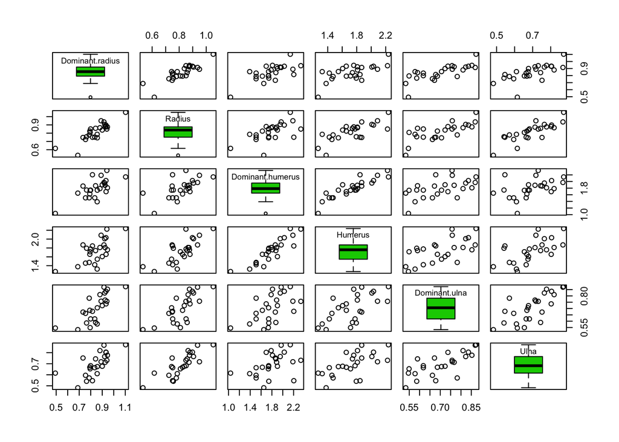

```r
scatterplotMatrix(t1_8[,1:ncol(t1_8)], diagonal="boxplot", smoother=F,reg.line=F)
```

For all columns in Table1.9, I plot them with boxplots

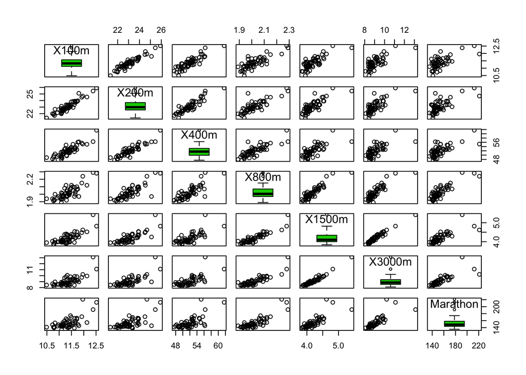

```r
scatterplotMatrix(t1_9_time[,1:ncol(t1_9_time)],diagonal="boxplot", smoother=F, reg.line=F)
```